# Annotation of amr determinants

Produced with bacannot pipeline

06 July 2024

# ecoli ARGs report

## About

Antimicrobial resistance genes (ARGs) are genes that encode resistance determinants capable of conferring to the bacteria the ability to tolerate or resist some antibiotics or antimicrobials, making bacteria less susceptible to its effects. In this pipeline, ARGs have been predicted/detected with four main AMR resources:

1. [Resfinder](https://cge.cbs.dtu.dk/services/ResFinder/)
   - Resfinder is a very popular database of acquired resistance genes and chromosomal point mutations hosted by the Center for Genomic Epidemiology.
2. [AMRFinderPlus](https://github.com/ncbi/amr/wiki)
   - AMRFinder is a software distributed by NCBI that allows users to query the National Database of Antibiotic Resistant Organisms ([NDARO](https://www.ncbi.nlm.nih.gov/pathogens/antimicrobial-resistance/)).
   - NDARO is a NCBI curated database that aggregates resistance genes from other databases such as [Resfams](http://www.dantaslab.org/resfams), [CARD](https://card.mcmaster.ca/), [Resfinder](https://cge.cbs.dtu.dk/services/ResFinder/), Pasteur Institute Beta Lactamases and others.
   - For more information please read the following [link](https://www.ncbi.nlm.nih.gov/bioproject/PRJNA313047). NCBI’s efforts were done in order to standardize and confer reliability to AMR predictions.
3. [CARD RGI](https://github.com/arpcard/rgi)
   - RGI is a software distributed by the CARD database which enables the detection of new variants and mutations that confer resistance to antibiotics, analyzing genomes or proteome sequences under three paradigms: **Perfect**, **Strict**, and **Loose** (a.k.a. Discovery).
   - **The Perfect algorithm** is most often applied to clinical surveillance as it detects perfect matches to the curated reference sequences and mutations in the CARD database.
   - In contrast, **the Strict algorithm** detects previously unknown variants of known AMR genes, including secondary screen for key mutations, using detection models with CARD’s curated similarity cut-offs to ensure the detected variant is likely a functional AMR gene.
4. [ARGminer](https://bench.cs.vt.edu/argminer/#/home)
   - RGminer database is an online resource for the inspection and curation of ARGs based on crowdsourcing as well as a platform to promote interaction and collaboration for the ARG scientific community. It is used in this pipeline in order to diversify the insights about the resistance genes found. It can not be used as the sole source of prediction, but it may be a useful contribution for analyses and AMR descriptions because it tries to aggregate and create nomenclature standards between databases.

### Prediction thresholds

All the predictions were passed through a user defined threshold for minimum coverage and identity:

- Min. Identity (%): `> 90`
- Min. Coverage (%): `> 90`

> [CARD RGI](https://github.com/arpcard/rgi) have their own detection models thresholds obtained by curation. Therefore, the only result from CARD that have been filtered like that is their final tabular output (shown in this report).

> The results used to create this report are under the directory called `resistance` in the output folder of the query ecoli.

## Resfinder

No AMR gene was annotated either because [Resfinder](https://cge.cbs.dtu.dk/services/ResFinder/) has not been executed (based on user’s input parameters) or the given alignment thresholds were too strict. If you believe that at least one gene should be present in the query genome you may try different thresholds.

## CARD RGI

The results obtained with RGI tool are summarized in the heatmap produced by the tool itself (Figure 1). Additionally, the annotation results are also shown in an interactive table displaying the tool’s complete annotation information (Table 1). They can be roughly divided into two main categories:

1. Perfect hits
   - detects perfect matches to the curated reference sequences and mutations in the CARD
2. Strict hits
   - detects previously unknown variants of known AMR genes, including secondary screen for key mutations, using detection models with CARD’s curated similarity cut-offs to ensure the detected variant is likely a functional AMR gene

> **Obs:** CARD RGI tool always tries to annotate functional AMR genes, however, depending on the assembly, a not functional gene may yet be annotated. Therefore, users are advised to double check genes annotated under **Strict** category.

Table 1: RGI annotation results. The perfect hits are highlighted in yellow while the strict hits in light blue.

| Generic_ID | Product | AMR Gene Family | Drug Class | Resistance Mechanism | CVTERM.ID | Query Protein Coordinates | Cut_Off |
| --- | --- | --- | --- | --- | --- | --- | --- |
| AAPFGBLB_00925 | Escherichia coli mdfA | major facilitator superfamily (MFS) antibiotic efflux pump | tetracycline antibiotic; disinfecting agents and antiseptics | antibiotic efflux | 37727 | NC_002695.2:1008961-1010193 | Strict |
| AAPFGBLB_01001 | msbA | ATP-binding cassette (ABC) antibiotic efflux pump | nitroimidazole antibiotic | antibiotic efflux | 40720 | NC_002695.2:1096264-1098012 | Perfect |
| AAPFGBLB_01412 | mdtG | major facilitator superfamily (MFS) antibiotic efflux pump | phosphonic acid antibiotic | antibiotic efflux | 37728 | NC_002695.2:1473546-1474517 | Strict |
| AAPFGBLB_01424 | mdtH | major facilitator superfamily (MFS) antibiotic efflux pump | fluoroquinolone antibiotic | antibiotic efflux | 37615 | NC_002695.2:1483403-1484611 | Strict |
| AAPFGBLB_01584 | Escherichia coli emrE | small multidrug resistance (SMR) antibiotic efflux pump | macrolide antibiotic | antibiotic efflux | 41083 | NC_002695.2:1621711-1622043 | Strict |
| AAPFGBLB_01708 | H-NS | major facilitator superfamily (MFS) antibiotic efflux pump; resistance-nodulation-cell division (RND) antibiotic efflux pump | macrolide antibiotic; fluoroquinolone antibiotic; cephalosporin; cephamycin; penam; tetracycline antibiotic | antibiotic efflux | 37020 | NC_002695.2:1737691-1738104 | Perfect |
| AAPFGBLB_02108 | Escherichia coli AcrAB-TolC with MarR mutations conferring resistance to ciprofloxacin and tetracycline | resistance-nodulation-cell division (RND) antibiotic efflux pump | fluoroquinolone antibiotic; cephalosporin; glycylcycline; penam; tetracycline antibiotic; rifamycin antibiotic; phenicol antibiotic; disinfecting agents and antiseptics | antibiotic target alteration; antibiotic efflux | 39962 | NC_002695.2:2143668-2144102 | Strict |
| AAPFGBLB_02109 | marA | resistance-nodulation-cell division (RND) antibiotic efflux pump; General Bacterial Porin with reduced permeability to beta-lactams | fluoroquinolone antibiotic; monobactam; carbapenem; cephalosporin; glycylcycline; cephamycin; penam; tetracycline antibiotic; rifamycin antibiotic; phenicol antibiotic; penem; disinfecting agents and … | antibiotic efflux; reduced permeability to antibiotic | 36402 | NC_002695.2:2144122-2144505 | Perfect |
| AAPFGBLB_02810 | ugd | pmr phosphoethanolamine transferase | peptide antibiotic | antibiotic target alteration | 40187 | NC_002695.2:2770646-2771812 | Strict |
| AAPFGBLB_02859 | mdtA | resistance-nodulation-cell division (RND) antibiotic efflux pump | aminocoumarin antibiotic | antibiotic efflux | 37172 | NC_002695.2:2829585-2830832 | Strict |

[output cut: 41 more lines]

[figure not shown]

Figure 1: RGI’s phenotype prediction. AMR genes are listed in alphabetical order and unique resistome profiles are displayed with their frequency. Yellow represents a perfect hit, Blue-green represents a strict hit.

## AMRFinder

The AMRFinderPlus annotation results are summarized below in an interactive table containing the complete annotation information (Table 2) and an image displaying the targeted drug classes (Figure 2). Whenever possible, features are linked to the NCBI database marking the closest reference sequence to each annotated gene. The results obtained with AMRFinderPlus can be roughly divided into two main categories:

1. Genes related to antibiotics, called AMR;
2. Genes related to stress resistance which can be:
   - biocide resistance
   - metal resistance
   - heat resistance

### Acquired ARGs detected

- **AMR genes found in the query genome:**
  - emrD
  - blaEC
  - mdtM

### Supporting Data

Table 2: Resistance genes annotated from NCBI AMR curated database using AMRfinderplus

| Resistance type | Resistance subtype | Query protein | Gene | Product | Resistance Class | Resistance subclass | Detection method | Ref. Accession | Genomic coordinates |
| --- | --- | --- | --- | --- | --- | --- | --- | --- | --- |
| AMR | AMR | AAPFGBLB_04628 | emrD | multidrug efflux MFS transporter EmrD | EFFLUX | EFFLUX | BLASTP | BAE77620.1 | NC_002695.2:4644522-4645706 |
| AMR | AMR | AAPFGBLB_05184 | blaEC | BlaEC family class C beta-lactamase | BETA-LACTAM | BETA-LACTAM | BLASTP | WP_063610930.1 | NC_002695.2:5232218-5233351 |
| AMR | AMR | AAPFGBLB_05350 | mdtM | multidrug efflux MFS transporter MdtM | EFFLUX | EFFLUX | BLASTP | AAC77293.1 | NC_002695.2:5430530-5431762 |
| STRESS | METAL | AAPFGBLB_01336 | terW | tellurium resistance protein TerW | TELLURIUM | TELLURIUM | BLASTP | AAC44736.1 | NC_002695.2:1405599-1406066 |
| STRESS | METAL | AAPFGBLB_01343 | terZ | tellurium resistance-associated protein TerZ | TELLURIUM | TELLURIUM | BLASTP | AAA86846.1 | NC_002695.2:1412639-1413220 |
| STRESS | METAL | AAPFGBLB_01345 | terB | tellurium resistance membrane protein TerB | TELLURIUM | TELLURIUM | BLASTP | ACI12150.1 | NC_002695.2:1414400-1414855 |
| STRESS | METAL | AAPFGBLB_01346 | terC | tellurium resistance membrane protein TerC | TELLURIUM | TELLURIUM | BLASTP | AAA98291.1 | NC_002695.2:1414878-1415918 |
| STRESS | METAL | AAPFGBLB_01347 | terD | tellurium resistance membrane protein TerD | TELLURIUM | TELLURIUM | BLASTP | AAA98292.1 | NC_002695.2:1415967-1416545 |
| STRESS | BIOCIDE | AAPFGBLB_01584 | emrE | multidrug efflux SMR transporter EmrE | EFFLUX | EFFLUX | BLASTP | CAA77936.1 | NC_002695.2:1621711-1622043 |
| STRESS | ACID | AAPFGBLB_02278 | asr | acid resistance repetitive basic protein Asr | none | none | BLASTP | BAA15331.2 | NC_002695.2:2271314-2271622 |

[output cut: 4 more lines]

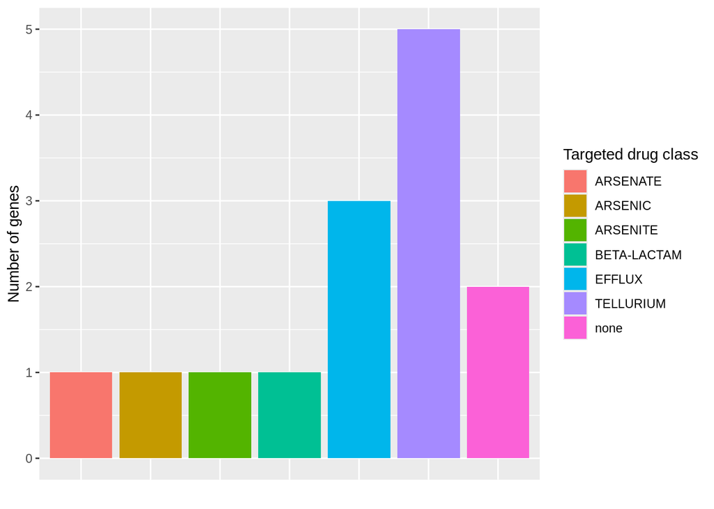

Figure 2: Resistome Predicted using NCBI’s AMRFinderplus

## ARGminer

ARGminer is an online resource for the inspection and curation of ARGs based on crowdsourcing as well as a platform to promote interaction and collaboration for the ARG scientific community. We put this database here in the report and annotation in order to support the initative and to help it go towards nomenclature simplification. Genes are scanned via `BLASTp` since ARGminer is a protein database. This alignment is summarized in table 3.

> It must be used with caution. Remember, it is a super new database thus it is rapidly changing and may yet contain errors.

### BLAST summary

Table 3: Resistance genes detected using ARGminer database via BLASTp

| Protein ID | Start | End | Strand | Gene Name | Coverage Map | Gaps | Coverage % | Identity % | Reference | Drug target |
| --- | --- | --- | --- | --- | --- | --- | --- | --- | --- | --- |
| AAPFGBLB_03231 | 1 | 1197 | + | evgS | 1-1197/1197 | 0/0 | 100 | 97.8 | AAC75429.1 | multidrug |
| AAPFGBLB_01472 | 17 | 1164 | + | mfd | 1-1148/1148 | 0/0 | 100 | 99.6 | NP_415632.1 | quinolone |
| AAPFGBLB_00506 | 1 | 1049 | + | acrB | 1-1049/1049 | 0/0 | 100 | 100 | NC_002695.1.914619.p01 | fluoroquinolone;cephalosporin;glycylcycline;penam;tetracycline;rifamycin;phenicol;triclosan |
| AAPFGBLB_02860 | 1 | 1040 | + | mdtB | 1-1040/1040 | 0/0 | 100 | 100 | NC_002695.1.916585.p01 | aminocoumarin |
| AAPFGBLB_04407 | 1 | 1037 | + | mdtF | 1-1037/1037 | 0/0 | 100 | 100 | YP_002272991 | macrolide;fluoroquinolone;penam |
| AAPFGBLB_03321 | 1 | 1037 | + | acrD | 1-1037/1037 | 0/0 | 100 | 99.8 | YP_490697.1 | aminoglycoside |
| AAPFGBLB_01832 | 1 | 1027 | + | acrB | 1-1027/1027 | 0/0 | 100 | 100 | NC_002695.1.912777.p01 | fluoroquinolone;cephalosporin;glycylcycline;penam;tetracycline;rifamycin;phenicol;triclosan |
| AAPFGBLB_02861 | 1 | 1025 | + | mdtC | 1-1025/1025 | 0/0 | 100 | 100 | NC_002695.1.916586.p01 | aminocoumarin |
| AAPFGBLB_05110 | 1 | 683 | + | MdtO | 1-683/683 | 0/0 | 100 | 100 | NP_290714 | multidrug |
| AAPFGBLB_03123 | 1 | 660 | + | arnA | 1-660/660 | 0/0 | 100 | 100 | YP_002271667 | peptide |

[output cut: 62 more lines]

## Prokka

Additionally, Prokka generically annotates a few proteins that are related to any type of resistance. These are showed in Table 4.

> When using Prokka, one must take caution when evaluating this result because this annotation can be very generic and therefore not so meaningful. Because it only uses hmms, sometimes the annotation of genes can be based on a single detected motif thus its results must be checked whether they are correctly annotated and/or functional.

Table 4: Generic annotation of resistance determinants by Prokka

| Contig | Start | End | Generic Annotation Product | Description |
| --- | --- | --- | --- | --- |
| NC_002695.2 | 5700 | 6476 | Peroxide stress resistance protein YaaA | ID=AAPFGBLB_00005;Name=yaaA;db_xref=COG:COG3022;gene=yaaA;inference=ab initio prediction:Prodigal:002006,similar to AA sequence:UniProtKB:P0A8I3;locus_tag=AAPFGBLB_00005;product=Peroxide stress resist… |
| NC_002695.2 | 454286 | 454909 | Inhibitor of hydrogen peroxide resistance | ID=AAPFGBLB_00416;Name=iprA;gene=iprA;inference=ab initio prediction:Prodigal:002006,protein motif:HAMAP:MF_02072;locus_tag=AAPFGBLB_00416;product=Inhibitor of hydrogen peroxide resistance |
| NC_002695.2 | 534935 | 536707 | putative multidrug resistance ABC transporter ATP-binding/permease protein YheI | ID=AAPFGBLB_00493;eC_number=3.6.3.-;Name=yheI;db_xref=COG:COG1132;gene=yheI;inference=ab initio prediction:Prodigal:002006,similar to AA sequence:UniProtKB:O07550;locus_tag=AAPFGBLB_00493;product=puta… |
| NC_002695.2 | 536700 | 538481 | Multidrug resistance-like ATP-binding protein MdlB | ID=AAPFGBLB_00494;eC_number=7.6.2.2;Name=mdlB;db_xref=COG:COG1132;gene=mdlB;inference=ab initio prediction:Prodigal:002006,similar to AA sequence:UniProtKB:P0AAG5;locus_tag=AAPFGBLB_00494;product=Mult… |
| NC_002695.2 | 547320 | 550469 | Multidrug efflux pump subunit AcrB | ID=AAPFGBLB_00506;Name=acrB_1;db_xref=COG:COG0841;gene=acrB_1;inference=ab initio prediction:Prodigal:002006,similar to AA sequence:UniProtKB:P31224;locus_tag=AAPFGBLB_00506;product=Multidrug efflux p… |
| NC_002695.2 | 550492 | 551685 | Multidrug efflux pump subunit AcrA | ID=AAPFGBLB_00507;Name=acrA;gene=acrA;inference=ab initio prediction:Prodigal:002006,similar to AA sequence:UniProtKB:P0AE06;locus_tag=AAPFGBLB_00507;product=Multidrug efflux pump subunit AcrA;Additio… |
| NC_002695.2 | 551827 | 552474 | HTH-type transcriptional regulator AcrR | ID=AAPFGBLB_00508;Name=acrR_1;db_xref=COG:COG1309;gene=acrR_1;inference=ab initio prediction:Prodigal:002006,similar to AA sequence:UniProtKB:P0ACS9;locus_tag=AAPFGBLB_00508;product=HTH-type transcrip… |
| NC_002695.2 | 569267 | 570487 | Fosmidomycin resistance protein | ID=AAPFGBLB_00523;Name=fsr;gene=fsr;inference=ab initio prediction:Prodigal:002006,similar to AA sequence:UniProtKB:P52067;locus_tag=AAPFGBLB_00523;product=Fosmidomycin resistance protein;Additional_d… |
| NC_002695.2 | 962106 | 962366 | Multiple stress resistance protein BhsA | ID=AAPFGBLB_00881;Name=bhsA_1;gene=bhsA_1;inference=ab initio prediction:Prodigal:002006,similar to AA sequence:UniProtKB:P0AB40;locus_tag=AAPFGBLB_00881;product=Multiple stress resistance protein Bhs… |
| NC_002695.2 | 1405599 | 1406066 | hypothetical protein | ID=AAPFGBLB_01336;inference=ab initio prediction:Prodigal:002006;locus_tag=AAPFGBLB_01336;product=hypothetical protein;Additional_database=NDARO;NDARO:Gene_Name=terW;NDARO:Gene_Product=tellurium_resis… |

[output cut: 56 more lines]